# Clustering Countries

```python
import pandas as pd
import warnings
warnings.filterwarnings('ignore')
import pandas as pd
import matplotlib.pyplot as plt
import seaborn as sns
import numpy as np
import datetime as dt
from datetime import timedelta
from sklearn.model_selection import GridSearchCV
from sklearn.preprocessing import StandardScaler
from sklearn.cluster import KMeans
from sklearn.metrics import silhouette_score,silhouette_samples
from sklearn.linear_model import LinearRegression,Ridge,Lasso
from sklearn.svm import SVR
from sklearn.metrics import mean_squared_error,r2_score
import statsmodels.api as sm
from statsmodels.tsa.api import Holt,SimpleExpSmoothing,ExponentialSmoothing
from sklearn.preprocessing import PolynomialFeatures
from statsmodels.tsa.stattools import adfuller
```

```python
covid=pd.read_csv("./covid_19_data.csv")
covid.head()
```

|  | SNo | ObservationDate | Province/State | Country/Region | Last Update | Confirmed | Deaths | Recovered |
| --- | --- | --- | --- | --- | --- | --- | --- | --- |
| 0 | 1 | 01/22/2020 | Anhui | Mainland China | 1/22/2020 17:00 | 1.0 | 0.0 | 0.0 |
| 1 | 2 | 01/22/2020 | Beijing | Mainland China | 1/22/2020 17:00 | 14.0 | 0.0 | 0.0 |
| 2 | 3 | 01/22/2020 | Chongqing | Mainland China | 1/22/2020 17:00 | 6.0 | 0.0 | 0.0 |
| 3 | 4 | 01/22/2020 | Fujian | Mainland China | 1/22/2020 17:00 | 1.0 | 0.0 | 0.0 |
| 4 | 5 | 01/22/2020 | Gansu | Mainland China | 1/22/2020 17:00 | 0.0 | 0.0 | 0.0 |

```python
covid.drop(["SNo"],1,inplace=True)
```

```python
countrywise=covid[covid["ObservationDate"]==covid["ObservationDate"].max()].groupby(["Country/Region"]).agg({"Confirmed":'sum',"Recovered":'sum',"Deaths":'sum'}).sort_values(["Confirmed"],ascending=False)
countrywise["Mortality"]=(countrywise["Deaths"]/countrywise["Confirmed"])*100
countrywise["Recovery"]=(countrywise["Recovered"]/countrywise["Confirmed"])*100
```

```python
countrywise["Active Cases"]=(countrywise["Confirmed"]-countrywise["Recovered"]-countrywise["Deaths"])
countrywise["Outcome Cases"]=(countrywise["Recovered"]+countrywise["Deaths"])
```

```python
country_date=covid.groupby(["Country/Region","ObservationDate"]).agg({"Confirmed":'sum',"Recovered":'sum',"Deaths":'sum'})
confirm_rate=[]
for country in countrywise.index:
    days=country_date.loc[country].shape[0]
    confirm_rate.append((countrywise.loc[country]["Confirmed"])/days)
countrywise["Confirm Cases/Day"]=confirm_rate
```

```python
countrywise["Survival Probability"]=(1-(countrywise["Deaths"]/countrywise["Confirmed"]))*100
```

# We consider 3 features for each country:

- Number of Confirmed cases
- Number of Deaths
- Number of Recovered cases

```python
X=countrywise[["Confirmed","Deaths","Recovered"]]
```

```python
from sklearn.preprocessing import StandardScaler
std=StandardScaler()
X=std.fit_transform(X)
```

```python
wcss = []
sil=[]
for i in range(2,11):
    clf=KMeans(n_clusters=i,init='k-means++',random_state=42)
    clf.fit(X)
    labels=clf.labels_
    centroids=clf.cluster_centers_
    sil.append(silhouette_score(X, labels, metric='euclidean'))
    wcss.append(clf.inertia_)
```

```
[0.9584887333556031,
 0.9073840553250063,
 0.9003379271469037,
 0.9048045334235529,
 0.8232460540462491,
 0.8212845851968483,
 0.8184508558795199,
 0.8194689225066665,
 0.8186409258014021]
```

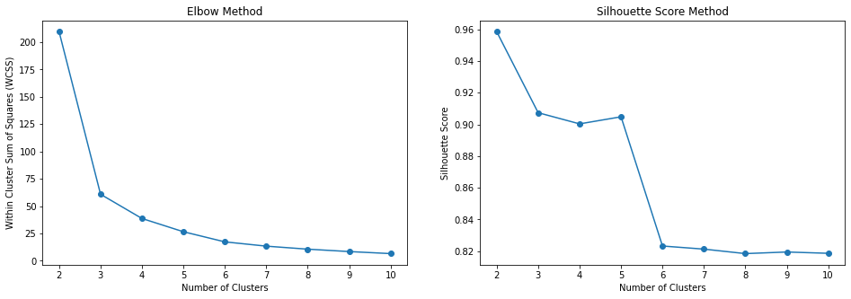

```python
fig, (ax1, ax2) = plt.subplots(1, 2,figsize=(16,5))
x=np.arange(2,11)
ax1.plot(x,wcss,marker='o')
ax1.set_xlabel("Number of Clusters")
ax1.set_ylabel("Within Cluster Sum of Squares (WCSS)")
ax1.set_title("Elbow Method")

x=np.arange(2,11)
ax2.plot(x,sil,marker='o')
ax2.set_xlabel("Number of Clusters")
ax2.set_ylabel("Silhouette Score")
ax2.set_title("Silhouette Score Method")
sil
```

# Lets consider K = 5

```python
clf_final=KMeans(n_clusters=5,init='k-means++',random_state=42)
clf_final.fit(X)
```

```
KMeans(algorithm='auto', copy_x=True, init='k-means++', max_iter=300,
       n_clusters=5, n_init=10, n_jobs=None, precompute_distances='auto',
       random_state=42, tol=0.0001, verbose=0)
```

```python
countrywise["Clusters"]=clf_final.predict(X)
```

# Summary of clusters

```python
cluster_summary=pd.concat([countrywise[countrywise["Clusters"]==1],countrywise[countrywise["Clusters"]==2],countrywise[countrywise["Clusters"]==3],countrywise[countrywise["Clusters"]==4],countrywise[countrywise["Clusters"]==0].head(15)])
cluster_summary.style.background_gradient(cmap='Reds')
```

| Country/Region | Confirmed | Recovered | Deaths | Mortality | Recovery | Active Cases | Outcome Cases | Confirm Cases/Day | Survival Probability | Clusters |
| --- | --- | --- | --- | --- | --- | --- | --- | --- | --- | --- |
| US | 1486757.000000 | 272265.000000 | 89562.000000 | 6.023984 | 18.312677 | 1124930.000000 | 361827.000000 | 12707.324786 | 93.976016 | 1 |
| Spain | 230698.000000 | 146446.000000 | 27563.000000 | 11.947655 | 63.479527 | 56689.000000 | 174009.000000 | 2156.056075 | 88.052345 | 2 |
| Italy | 225435.000000 | 125176.000000 | 31908.000000 | 14.153969 | 55.526427 | 68351.000000 | 157084.000000 | 2087.361111 | 85.846031 | 2 |
| Russia | 281752.000000 | 67373.000000 | 2631.000000 | 0.933800 | 23.912164 | 211748.000000 | 70004.000000 | 2608.814815 | 99.066200 | 3 |
| Brazil | 241080.000000 | 94122.000000 | 16118.000000 | 6.685747 | 39.041812 | 130840.000000 | 110240.000000 | 2904.578313 | 93.314253 | 3 |
| Germany | 176369.000000 | 154011.000000 | 7962.000000 | 4.514399 | 87.323169 | 14396.000000 | 161973.000000 | 1588.909910 | 95.485601 | 3 |
| Turkey | 149435.000000 | 109962.000000 | 4140.000000 | 2.770435 | 73.585171 | 35333.000000 | 114102.000000 | 2197.573529 | 97.229565 | 3 |
| Iran | 120198.000000 | 94464.000000 | 6988.000000 | 5.813741 | 78.590326 | 18746.000000 | 101452.000000 | 1350.539326 | 94.186259 | 3 |
| Mainland China | 82954.000000 | 78238.000000 | 4634.000000 | 5.586229 | 94.314922 | 82.000000 | 82872.000000 | 709.008547 | 94.413771 | 3 |
| UK | 244995.000000 | 1058.000000 | 34716.000000 | 14.170085 | 0.431846 | 209221.000000 | 35774.000000 | 2268.472222 | 85.829915 | 4 |
| France | 179693.000000 | 61327.000000 | 28111.000000 | 15.643904 | 34.128764 | 90255.000000 | 89438.000000 | 1562.547826 | 84.356096 | 4 |
| India | 95698.000000 | 36795.000000 | 3025.000000 | 3.160986 | 38.449079 | 55878.000000 | 39820.000000 | 877.963303 | 96.839014 | 0 |
| Peru | 92273.000000 | 28621.000000 | 2648.000000 | 2.869745 | 31.017741 | 61004.000000 | 31269.000000 | 1264.013699 | 97.130255 | 0 |
| Canada | 78332.000000 | 38563.000000 | 5903.000000 | 7.535873 | 49.230200 | 33866.000000 | 44466.000000 | 693.203540 | 92.464127 | 0 |
| Belgium | 55280.000000 | 14630.000000 | 9052.000000 | 16.374819 | 26.465268 | 31598.000000 | 23682.000000 | 531.538462 | 83.625181 | 0 |
| Saudi Arabia | 54752.000000 | 25722.000000 | 312.000000 | 0.569842 | 46.979106 | 28718.000000 | 26034.000000 | 711.064935 | 99.430158 | 0 |
| Mexico | 49219.000000 | 33329.000000 | 5177.000000 | 10.518296 | 67.715720 | 10713.000000 | 38506.000000 | 607.641975 | 89.481704 | 0 |
| Netherlands | 44195.000000 | 167.000000 | 5699.000000 | 12.895124 | 0.377871 | 38329.000000 | 5866.000000 | 545.617284 | 87.104876 | 0 |
| Chile | 43781.000000 | 19213.000000 | 450.000000 | 1.027843 | 43.884333 | 24118.000000 | 19663.000000 | 576.065789 | 98.972157 | 0 |
| Pakistan | 40151.000000 | 11341.000000 | 873.000000 | 2.174292 | 28.245872 | 27937.000000 | 12214.000000 | 489.646341 | 97.825708 | 0 |
| Ecuador | 33182.000000 | 3433.000000 | 2736.000000 | 8.245434 | 10.345971 | 27013.000000 | 6169.000000 | 425.410256 | 91.754566 | 0 |
| Qatar | 32604.000000 | 4370.000000 | 15.000000 | 0.046007 | 13.403263 | 28219.000000 | 4385.000000 | 412.708861 | 99.953993 | 0 |
| Switzerland | 30587.000000 | 27500.000000 | 1881.000000 | 6.149671 | 89.907477 | 1206.000000 | 29381.000000 | 368.518072 | 93.850329 | 0 |
| Sweden | 30143.000000 | 4971.000000 | 3679.000000 | 12.205155 | 16.491391 | 21493.000000 | 8650.000000 | 279.101852 | 87.794845 | 0 |
| Belarus | 29650.000000 | 9932.000000 | 165.000000 | 0.556492 | 33.497470 | 19553.000000 | 10097.000000 | 370.625000 | 99.443508 | 0 |
| Portugal | 29036.000000 | 4636.000000 | 1218.000000 | 4.194793 | 15.966387 | 23182.000000 | 5854.000000 | 377.090909 | 95.805207 | 0 |

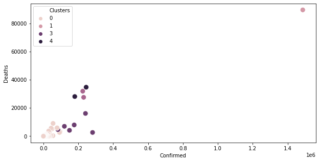

```python
plt.figure(figsize=(10,5))
sns.scatterplot(x=countrywise["Confirmed"],y=countrywise["Deaths"],hue=countrywise["Clusters"],s=100)
countrywise[["Confirmed", "Deaths", "Clusters"]].to_csv('countrywise-clusters.csv')
```

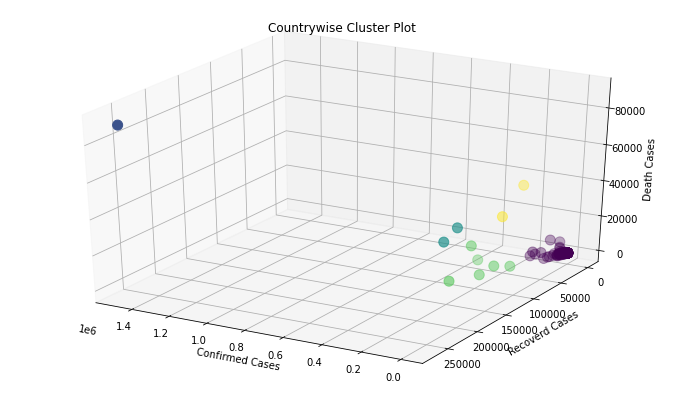

```python
from mpl_toolkits.mplot3d import Axes3D

fig = plt.figure(figsize=(12,7))
ax = fig.add_subplot(111, projection='3d')
ax.scatter(countrywise["Confirmed"],countrywise["Recovered"],countrywise["Deaths"], c=countrywise["Clusters"],
           marker='o',s=100)
ax.view_init(azim=120)
ax.set_xlabel('Confirmed Cases')
ax.set_ylabel('Recoverd Cases')
ax.set_zlabel('Death Cases')
plt.title("Countrywise Cluster Plot")
plt.show()
```

Cluster 0 is a set of countries which are very less affected, with comapritively low number of Confimed, Recoverd and Death Cases. e.g. India, Canada etc.

Cluster 1 is set of countries which are severly affected, with really high number of Confirmed, Recovered and Death Cases. e.g. United States is the only country which belongs to this Cluster.

Cluster 3 belongs to countries which are worst affected with high number of Confirmed Cases but having really good number of Recoverd Cases, with comparitively low Mortality Rate. e.g. Germany, Russia, Iran, Brazil etc.

Cluster 2 belongs to countries which are badly affected with high number of Confirmed Cases but having really good number of Recoverd Cases, but high Mortality Rate e.g. Italy, Spain etc.

Cluster 4 is somehow similar to Cluster 2, but high Mortality Rate compared to Cluster 2 also the number of Active Cases are high as compared to Cluster 2 e.g. United Kingdom, France etc.